# Agrupamiento-Universidades

Brayan Ortiz, Juan Peña, Thalea Hesse, Juan Falcon, Daniel Espinal

2022-06-11

# Procesamiento de los datos

El conjunto de datos cuentas con 1725 características, sin embargo muchas de ellas no contienen información. Por esta razón se deciden eliminar las característica que tengan más del 20% en valores NaN. Por otra parte, el conjunto de datos contiene diferentes formas para representar los valores vacíos, por ejemplo cadenas de texto vacías o con espacios y, adicionalmente, hay registros con valores en *PrivacySuppressed*. Todos estos valores se recopilaron y se replazaron por el objeto NA de R.

Existen variables (INSTNM, NPCURL, INSTURL) con todos los valores, pero no aportan información para el análisis. Estas columnas también fueron eliminadas del conjunto de datos.

## Convertir los tipos de datos

## Interpolación de los datos faltantes

Los datos numéricos faltantes se completan realizando una extrapolación de los datos que se tienen en la base datos. Se hacen separado para los datos numéricos y enteros.

# Componentes principales

Se decide realizar componentes principales agrupando variables que hacen parte de la misma descripción en el diccionario de datos. En particular, se obtienen las componentes principales de las variables que empiecen por PCIP (de las cuales hay 38) y UGDS (con 10 variables).

Las variables PCIP tienen el siguiente resumen de las componentes:

```
## Importance of components:
##                           Comp.1     Comp.2    Comp.3     Comp.4     Comp.5
## Standard deviation     2.1375802 1.34787322 1.2198109 1.16788187 1.13681894
## Proportion of Variance 0.1202588 0.04781566 0.0391613 0.03589797 0.03401376
## Cumulative Proportion  0.1202588 0.16807446 0.2072358 0.24313373 0.27714749
##                            Comp.6     Comp.7     Comp.8     Comp.9    Comp.10
## Standard deviation     1.07940189 1.06286865 1.05714311 1.03295346 1.02498641
## Proportion of Variance 0.03066468 0.02973249 0.02941302 0.02808236 0.02765084
## Cumulative Proportion  0.30781217 0.33754466 0.36695768 0.39504003 0.42269087
##                           Comp.11    Comp.12    Comp.13    Comp.14    Comp.15
## Standard deviation     1.00698807 1.00317693 1.00163784 0.99863064 0.99583932
## Proportion of Variance 0.02668829 0.02648666 0.02640545 0.02624713 0.02610061
## Cumulative Proportion  0.44937916 0.47586582 0.50227126 0.52851839 0.55461900
##                           Comp.16   Comp.17    Comp.18    Comp.19    Comp.20
## Standard deviation     0.99197977 0.9893472 0.97585075 0.96413096 0.96099223
## Proportion of Variance 0.02589868 0.0257614 0.02506333 0.02446494 0.02430591
## Cumulative Proportion  0.58051768 0.6062791 0.63134242 0.65580736 0.68011326
##                           Comp.21    Comp.22   Comp.23    Comp.24    Comp.25
## Standard deviation     0.95706675 0.95072620 0.9436426 0.93786497 0.93077799
## Proportion of Variance 0.02410774 0.02378937 0.0234362 0.02315009 0.02280154
## Cumulative Proportion  0.70422101 0.72801038 0.7514466 0.77459666 0.79739821
##                           Comp.26   Comp.27    Comp.28    Comp.29    Comp.30
## Standard deviation     0.92717471 0.9136877 0.88694567 0.87468987 0.85662367
## Proportion of Variance 0.02262535 0.0219719 0.02070456 0.02013633 0.01931311
## Cumulative Proportion  0.82002355 0.8419955 0.86270002 0.88283634 0.90214945
##                           Comp.31    Comp.32    Comp.33    Comp.34    Comp.35
## Standard deviation     0.84119683 0.79849261 0.77915211 0.75346985 0.70100159
## Proportion of Variance 0.01862376 0.01678085 0.01597778 0.01494183 0.01293332
## Cumulative Proportion  0.92077321 0.93755406 0.95353184 0.96847367 0.98140699
##                            Comp.36     Comp.37      Comp.38
## Standard deviation     0.601481955 0.561389894 0.1717691245
## Proportion of Variance 0.009521761 0.008294711 0.0007765372
## Cumulative Proportion  0.990928752 0.999223463 1.0000000000
```

De lo anterior, se puede observar que las primeras 25 componentes explican, aproximadamente, el 80% de la variabilidad. En el siguiente gráfico se muestra la varianza explicada por la primeras 10 componentes:

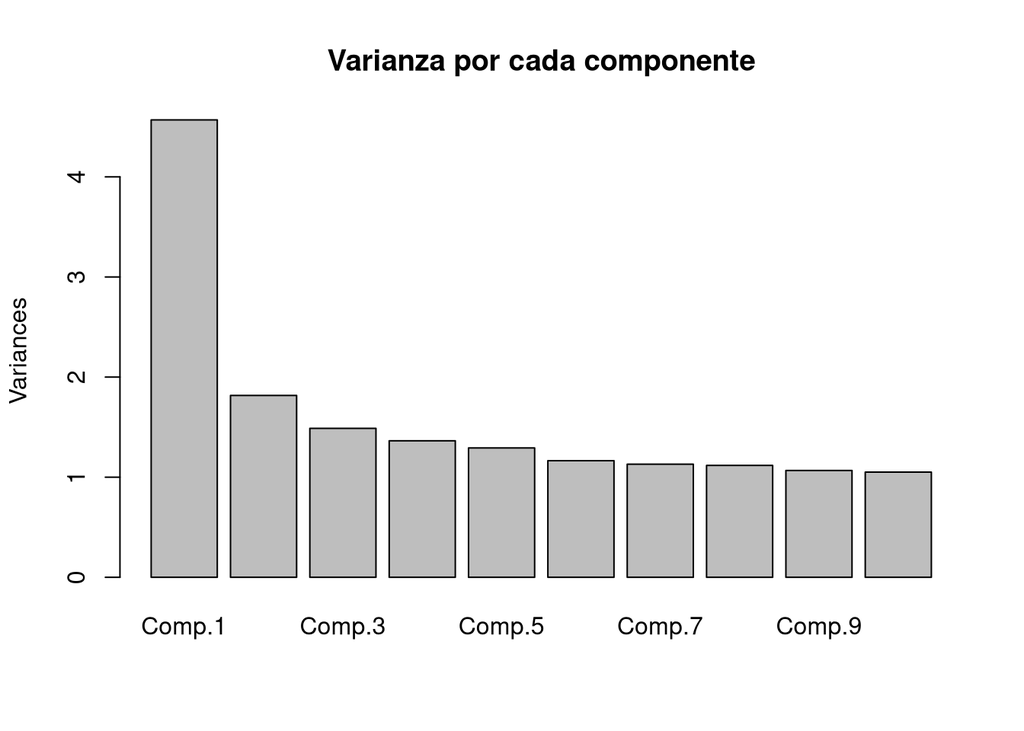

Para determinar la cantidad óptima de componentes con base a una explicación de la variabilidad del 80%, se calcula la variabilidad acumulada de las componentes y se obtiene la mínima componente con un 80% aproximado de esta:

```
## Comp.25
##      25
```

Para ver gráficamente lo anterior:

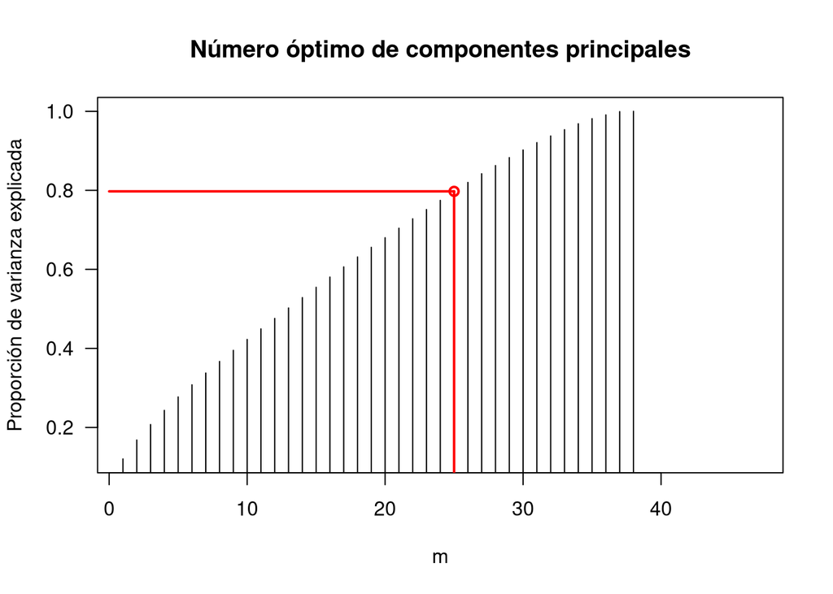

Análogamente, se hace un análisis de componentes principales para las variables UGDS.

En el siguiente resumen, se puede determinar que con 7 componentes se alcanza a explicar el 80% de la variabilidad de los datos:

```
## Importance of components:
##                           Comp.1    Comp.2    Comp.3    Comp.4    Comp.5
## Standard deviation     1.3015814 1.2284781 1.0832717 1.0435788 1.0166050
## Proportion of Variance 0.1694331 0.1509352 0.1173628 0.1089196 0.1033618
## Cumulative Proportion  0.1694331 0.3203683 0.4377311 0.5466507 0.6500125
##                            Comp.6     Comp.7     Comp.8     Comp.9      Comp.10
## Standard deviation     0.99663736 0.96214069 0.92250004 0.85096331 0.0726673529
## Proportion of Variance 0.09934133 0.09258333 0.08511154 0.07242314 0.0005281221
## Cumulative Proportion  0.74935387 0.84193720 0.92704874 0.99947188 1.0000000000
```

El análisis análitico lo confirma:

```
## Comp.7
##      7
```

# Componentes principales de los datos categóricos

```r
# Ejemplo: http://www.css.cornell.edu/faculty/dgr2/_static/files/R_html/NonlinearPCA.html
# pero no termina ...
# cols_prin_fact <- princals(df_fact, ndim = 2, ordinal = FALSE, itmax=5)
```

[figure not shown]

## Proyección de los datos en las componentes

A continuación se representa cada conjunto de datos en sus componentes principales multiplicando por la cantidad óptima de vectore propios de cada conjunto. Estos vectores propios los devuelve el método *princomp*.

A manera de resumen, se presenta los valores óptimos para cada conjunto de variables:

- **PCIP**: 25 componentes.
- **UGDS**: 7 componentes.

En las variables PCIP se tienen las siguientes proyecciones:

```
##   Comp.1_PCIP Comp.2_PCIP Comp.3_PCIP Comp.4_PCIP Comp.5_PCIP Comp.6_PCIP
## 1   3.3169488   0.5535598  -0.2049473  -0.3350232   0.6497079   0.4555247
## 2   3.2338757   0.0705724  -0.4413881   0.1131638  -0.2872371  -0.6107808
## 3  -0.8916711   0.6818379  -0.1877507   0.4453540   1.5347619   1.5521980
## 4   3.4776469  -0.3839782   0.9875211  -0.9790135  -1.0571109   0.1843568
## 5   3.1113654   1.2207451  -2.1705436   0.1208380   0.4753997  -1.3098587
## 6   2.5119252   0.6048897  -0.7196944   0.2023975   0.6729002  -0.1864281
##   Comp.7_PCIP Comp.8_PCIP Comp.9_PCIP Comp.10_PCIP Comp.11_PCIP Comp.12_PCIP
## 1   1.5948700   2.1326079  -0.2405269    0.2930793   0.07662768  0.373776732
## 2   0.1753725   0.7215763  -0.1973927   -0.4634315  -0.20677880 -0.006458703
## 3   0.1423195  -0.9813418  -1.8936280    0.2627951  -0.29522667  0.224671947
## 4   1.8040304   2.9115343  -1.0760530   -1.4279437  -0.21596072  0.029702192
## 5  -0.1889994   0.7676851   0.4169623    0.2418278  -0.20864612  0.046714494
## 6   0.7000558   0.3609508   0.1085291   -1.1385155   0.11253195  0.414663802
##   Comp.13_PCIP Comp.14_PCIP Comp.15_PCIP Comp.16_PCIP Comp.17_PCIP Comp.18_PCIP
```

[output cut: 20 more lines]

Similarmente, se tiene para las variables UGDS:

```
##   Comp.1_UGDS Comp.2_UGDS Comp.3_UGDS Comp.4_UGDS Comp.5_UGDS Comp.6_UGDS
## 1   1.7220423  -2.6209194  1.50095694   1.6141785 -0.78980058   0.7241277
## 2  -0.3455649   0.6796150  0.61772478   0.8726969  0.12252379   0.2501017
## 3   0.7012158  -1.4346732  1.50566397  -0.5820641  1.00681465   0.1021009
## 4  -0.8184817   0.5497745  0.09489257   0.4799155  0.09346711   0.3141943
## 5   1.7875981  -2.2357663  1.62128844   1.7313388 -0.63039172   0.8830594
## 6  -1.0470876   2.0112819  0.20993812   1.9722533  1.20089116   0.5996408
##   Comp.7_UGDS
## 1  0.72699356
## 2  1.30304118
## 3 -0.97505643
## 4  0.04063925
## 5  0.71548250
## 6  2.93874384
```

## Reconstrucción del conjunto de datos

Como se calcularon las componentes para un subconjunto de variables, entonces es necesario unificar estos nuevos valores proyectados con las variables a las cuales no se les calculó componentes. Para esto, se eliminan del conjunto de datos las variables que fueron proyectadas y se añaden sus proyecciones, mientras que las demás variables permanencen iguales.

Estas fueron las variables que quedaron en el conjunto de datos:

```
##  [1] "NUMBRANCH"              "LATITUDE"               "LONGITUDE"
##  [4] "PPTUG_EF"               "TUITFTE"                "INEXPFTE"
##  [7] "PCTPELL"                "poolyrs"                "PCTFLOAN"
## [10] "UG25abv"                "CDR3"                   "DEP_STAT_PCT_IND"
## [13] "PAR_ED_PCT_1STGEN"      "PAR_ED_PCT_MS"          "PAR_ED_PCT_HS"
## [16] "PAR_ED_PCT_PS"          "APPL_SCH_PCT_GE2"       "APPL_SCH_PCT_GE3"
## [19] "APPL_SCH_PCT_GE4"       "DEP_INC_AVG"            "IND_INC_AVG"
## [22] "DEBT_MDN"               "GRAD_DEBT_MDN"          "WDRAW_DEBT_MDN"
## [25] "FIRSTGEN_DEBT_MDN"      "NOTFIRSTGEN_DEBT_MDN"   "DEBT_N"
## [28] "GRAD_DEBT_N"            "WDRAW_DEBT_N"           "FIRSTGEN_DEBT_N"
## [31] "NOTFIRSTGEN_DEBT_N"     "GRAD_DEBT_MDN10YR"      "CUML_DEBT_N"
## [34] "CUML_DEBT_P75"          "CUML_DEBT_P25"          "DEP_INC_N"
## [37] "IND_INC_N"              "PAR_ED_N"               "APPL_SCH_N"
## [40] "RPY_3YR_N"              "DEBT_MDN_SUPP"          "GRAD_DEBT_MDN_SUPP"
## [43] "GRAD_DEBT_MDN10YR_SUPP" "RPY_3YR_RT_SUPP"        "Comp.1_PCIP"
## [46] "Comp.2_PCIP"            "Comp.3_PCIP"            "Comp.4_PCIP"
## [49] "Comp.5_PCIP"            "Comp.6_PCIP"            "Comp.7_PCIP"
## [52] "Comp.8_PCIP"            "Comp.9_PCIP"            "Comp.10_PCIP"
## [55] "Comp.11_PCIP"           "Comp.12_PCIP"           "Comp.13_PCIP"
## [58] "Comp.14_PCIP"           "Comp.15_PCIP"           "Comp.16_PCIP"
## [61] "Comp.17_PCIP"           "Comp.18_PCIP"           "Comp.19_PCIP"
## [64] "Comp.20_PCIP"           "Comp.21_PCIP"           "Comp.22_PCIP"
## [67] "Comp.23_PCIP"           "Comp.24_PCIP"           "Comp.25_PCIP"
## [70] "Comp.1_UGDS"            "Comp.2_UGDS"            "Comp.3_UGDS"
## [73] "Comp.4_UGDS"            "Comp.5_UGDS"            "Comp.6_UGDS"
## [76] "Comp.7_UGDS"
```

# Modelo

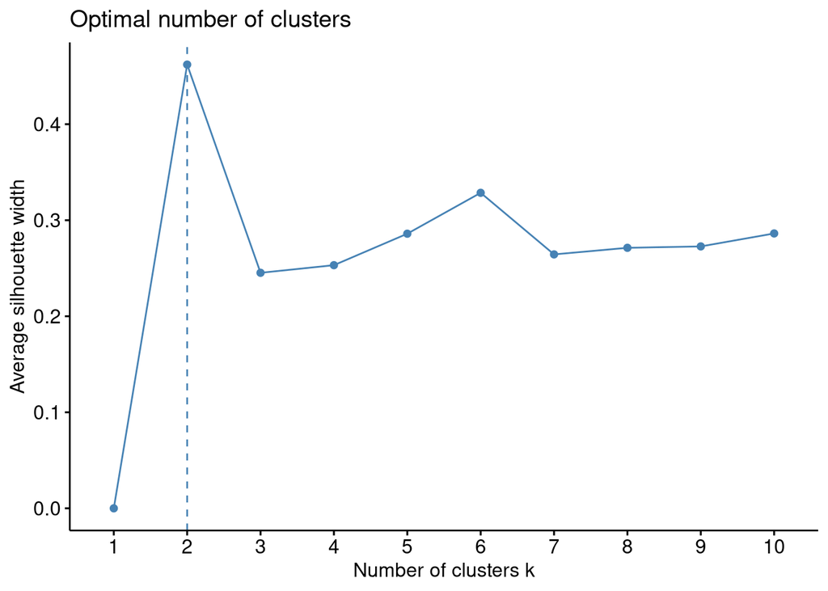

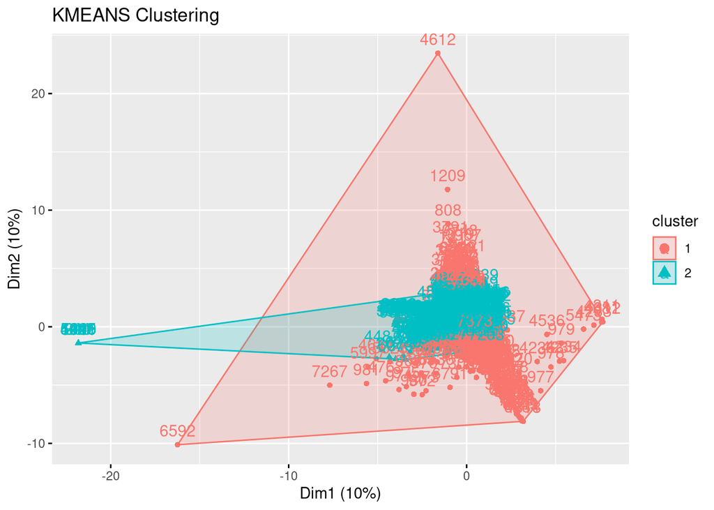

```
## K-means clustering with 2 clusters of sizes 656, 7148
##
## Cluster means:
##       Comp.1     Comp.2      Comp.3      Comp.4      Comp.5      Comp.6
## 1  1.1741006  2.7129651  0.58374958  0.89479593 -0.20313818  0.52587435
## 2 -0.1077518 -0.2489794 -0.05357299 -0.08211893  0.01864279 -0.04826155
##        Comp.7      Comp.8       Comp.9       Comp.10
## 1  0.17266935  0.30844499 -0.106137813 -3.325187e-04
## 2 -0.01584654 -0.02830721  0.009740683  3.051655e-05
##
## Clustering vector:
##    1    2    3    4    5    6    7    8    9   10   11   12   13   14   15   16
##    2    2    2    2    2    1    2    2    2    2    2    2    2    2    2    2
##   17   18   19   20   21   22   23   24   25   26   27   28   29   30   31   32
##    2    2    2    2    2    2    2    2    2    2    2    2    2    2    2    2
```

[output cut: 982 more lines]

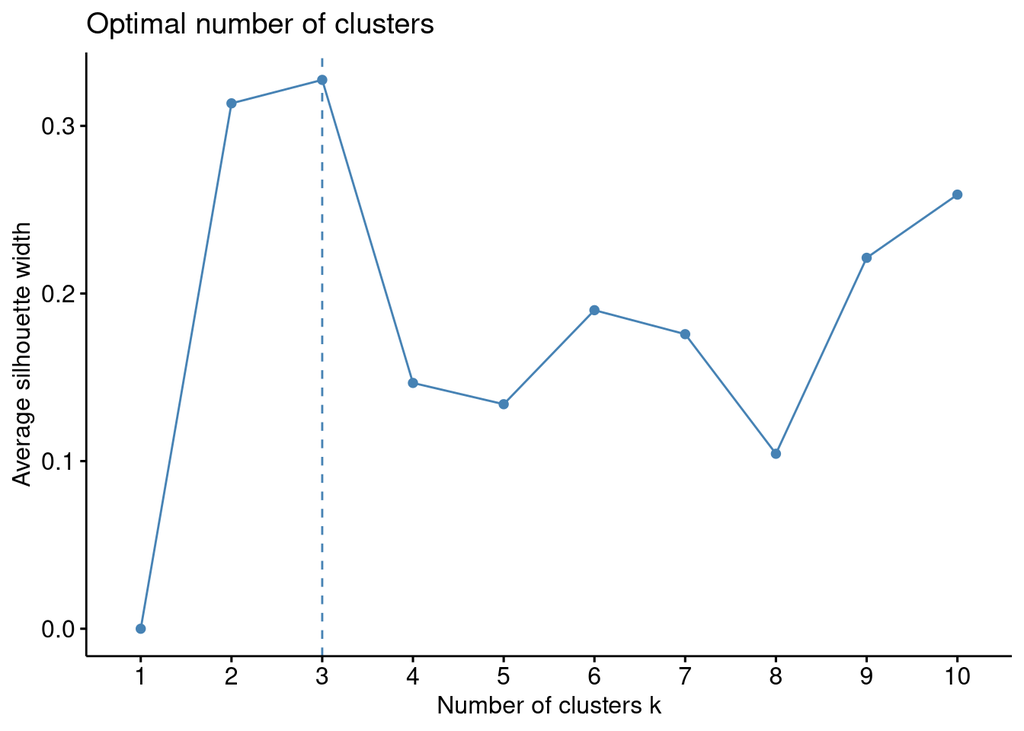

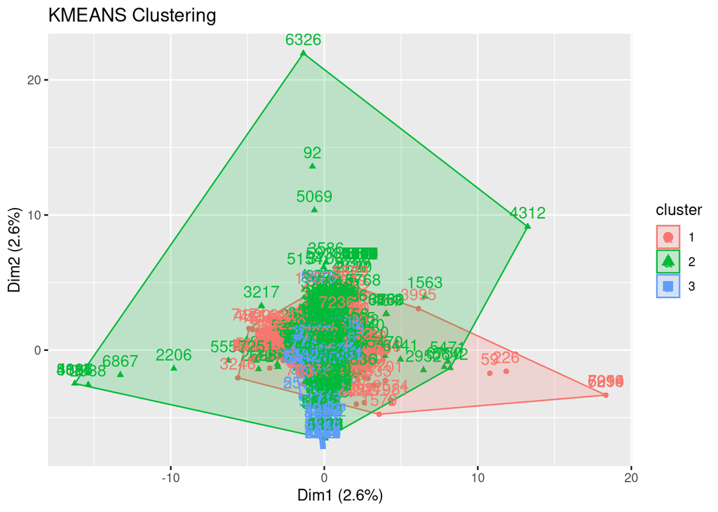

```
## K-means clustering with 3 clusters of sizes 1465, 5955, 384
##
## Cluster means:
##       Comp.1     Comp.2      Comp.3     Comp.4      Comp.5      Comp.6
## 1  3.8386354  0.1220555 -0.32527349  0.1174747  0.15462478 -0.25427873
## 2 -0.8820991 -0.1954280  0.04633597  0.1519554  0.02436278  0.07149568
## 3 -0.9653662  2.5650064  0.52238264 -2.8046740 -0.96772312 -0.13864175
##        Comp.7      Comp.8     Comp.9     Comp.10      Comp.11      Comp.12
## 1  0.04472190  0.20741514  0.1258734  0.03006928  0.004181782  0.022057501
## 2  0.01747333 -0.07844769 -0.0119470 -0.03154760  0.036269743  0.009070224
## 3 -0.44159182  0.42524175 -0.2949484  0.37451682 -0.578418308 -0.224810998
##        Comp.13      Comp.14     Comp.15      Comp.16     Comp.17     Comp.18
## 1 -0.015769882  0.008220336 -0.01555080 -0.003829118 -0.04086876  0.02249766
## 2 -0.008940138 -0.051856467 -0.04201796  0.009000143  0.03221628  0.03515741
## 3  0.198805724  0.772818930  0.71093459 -0.124964050 -0.34368538 -0.63104543
```

[output cut: 1004 more lines]

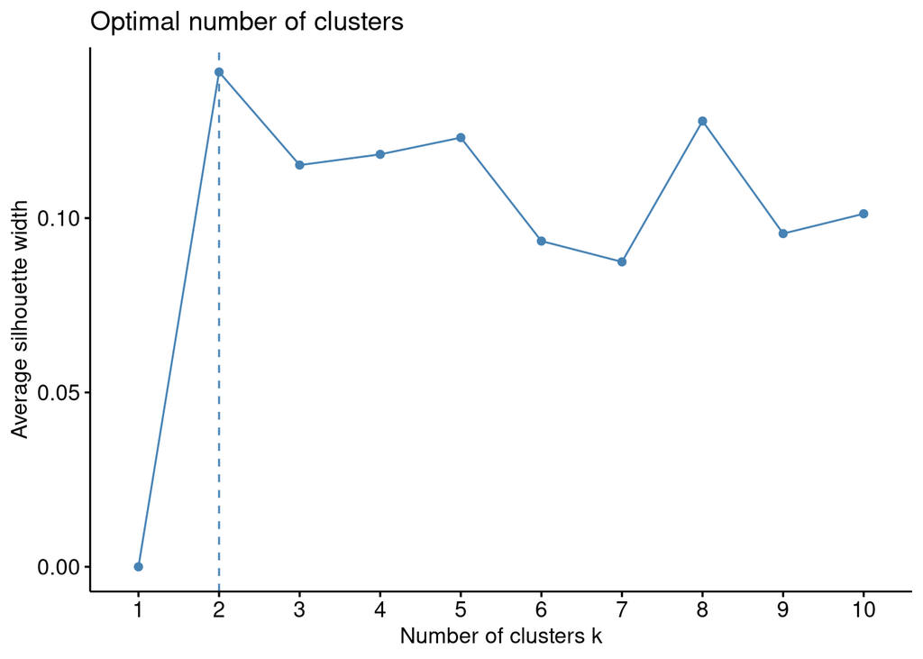

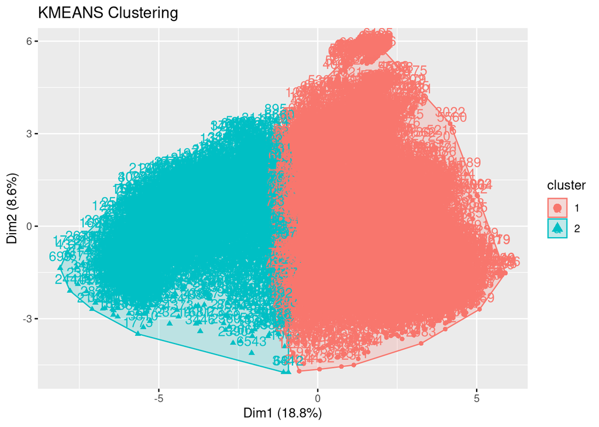

```
## K-means clustering with 2 clusters of sizes 5503, 2301
##
## Cluster means:
##    NUMBRANCH   LATITUDE   LONGITUDE   PPTUG_EF    TUITFTE   INEXPFTE   PCTPELL
## 1  0.1173048 -0.0627919 -0.04707916  0.1305768 -0.1646293 -0.1947743  0.271863
## 2 -0.2805426  0.1501711  0.11259305 -0.3122835  0.3937223  0.4658162 -0.650179
##      poolyrs  PCTFLOAN    UG25abv       CDR3 DEP_STAT_PCT_IND PAR_ED_PCT_1STGEN
## 1  0.0484910 -0.100003  0.3300066  0.2281786        0.4175374         0.4734072
## 2 -0.1159696  0.239164 -0.7892335 -0.5457049       -0.9985694        -1.1321860
##   PAR_ED_PCT_MS PAR_ED_PCT_HS PAR_ED_PCT_PS APPL_SCH_PCT_GE2 APPL_SCH_PCT_GE3
## 1     0.3782305     0.4586386    -0.4723283       -0.4065224       -0.4261026
## 2    -0.9045644    -1.0968658     1.1296055        0.9722264        1.0190538
##   APPL_SCH_PCT_GE4 DEP_INC_AVG IND_INC_AVG   DEBT_MDN GRAD_DEBT_MDN
## 1       -0.4285989  -0.3468657  -0.2180743  0.2704991    0.08460894
## 2        1.0250238   0.8295532   0.5215396 -0.6469173   -0.20234810
```

[output cut: 1003 more lines]

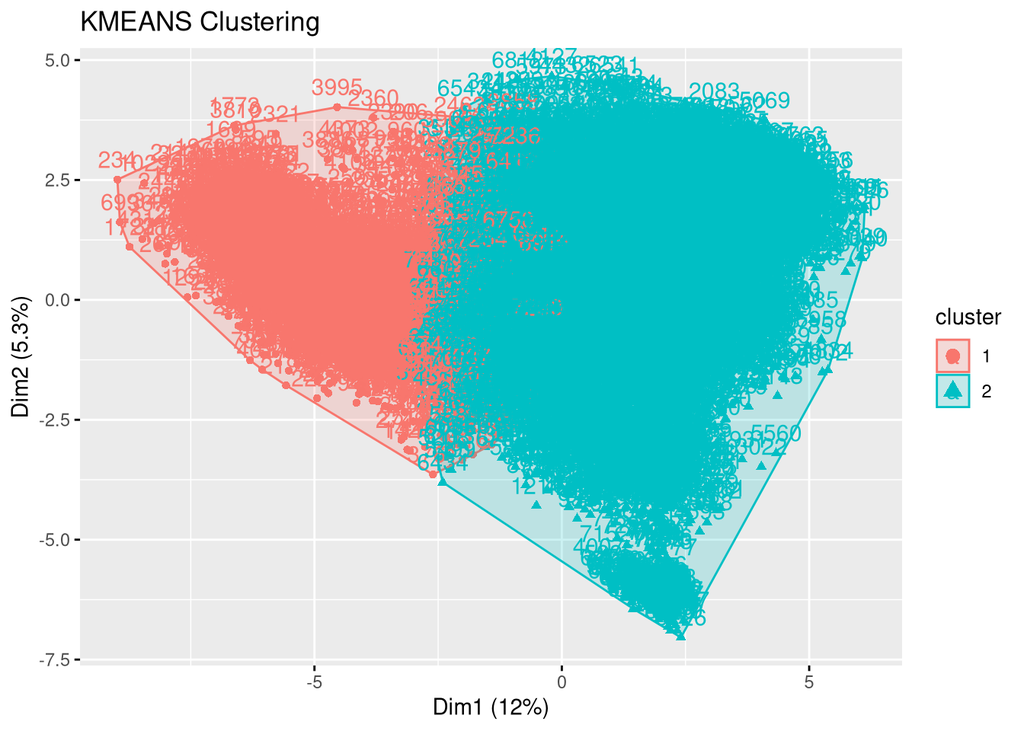